# Análisis de la distribución de las instituciones de educación especial en el Perú durante el año 2015

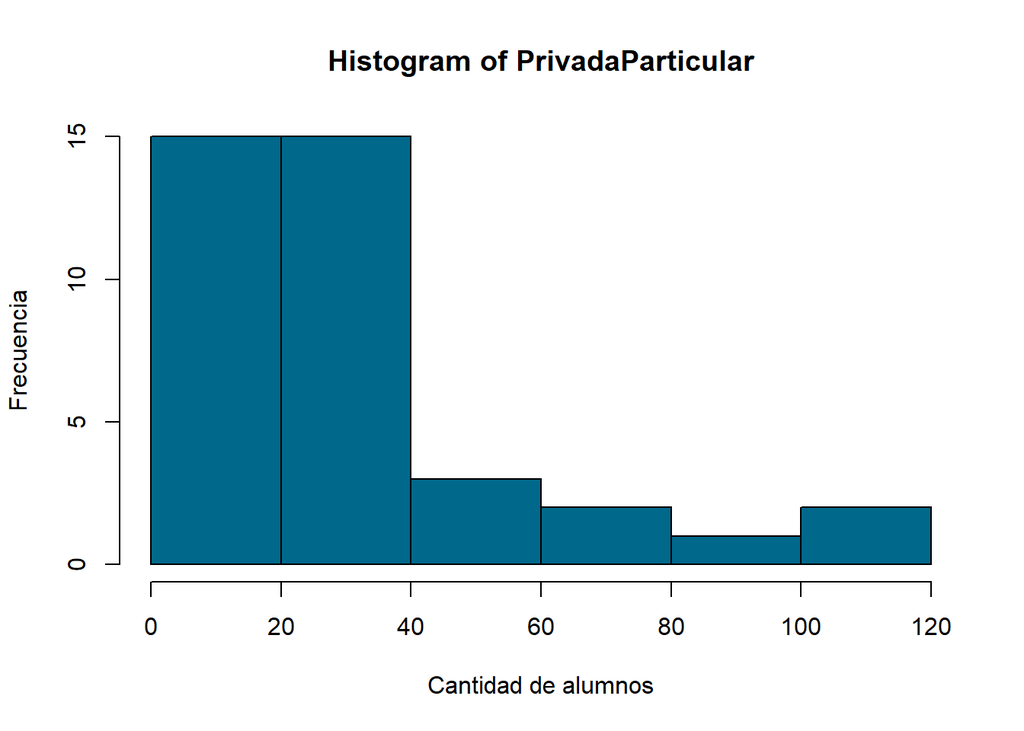

```r
hist(PrivadaParticular,xlab = "Cantidad de alumnos", ylab="Frecuencia",col=colors()[125])
```

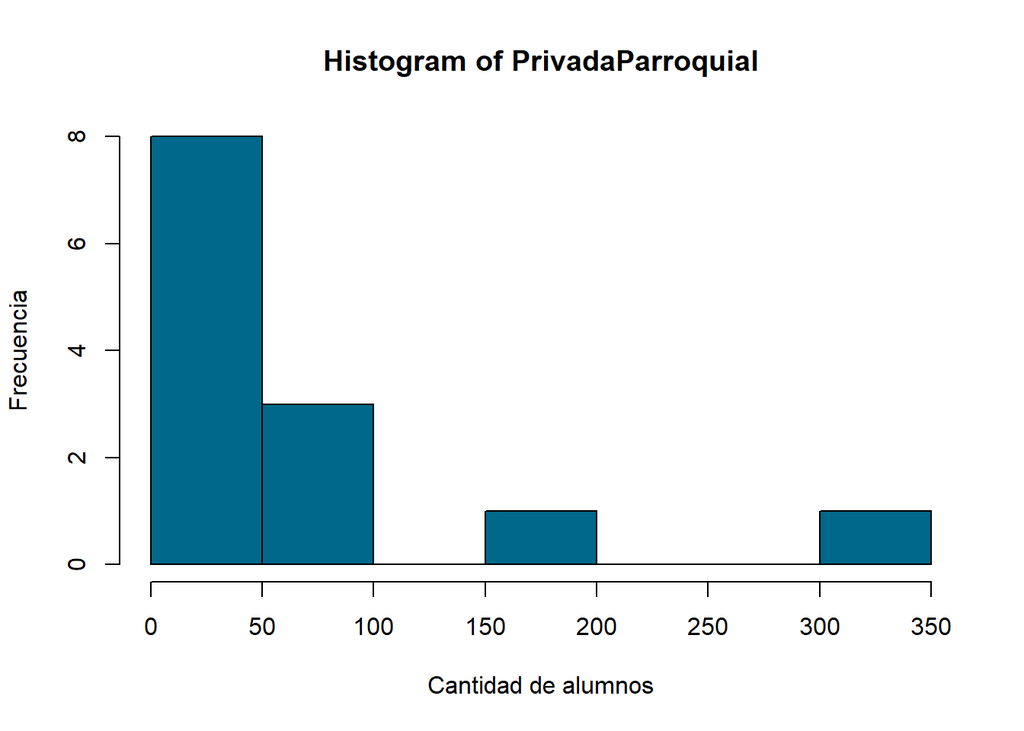

```r
hist(PrivadaParroquial,xlab = "Cantidad de alumnos", ylab="Frecuencia",col=colors()[125])
```

En este caso se muestra la relación entre la cantidad de alumnos por las diferentes regiones del país (costa, sierra y selva).

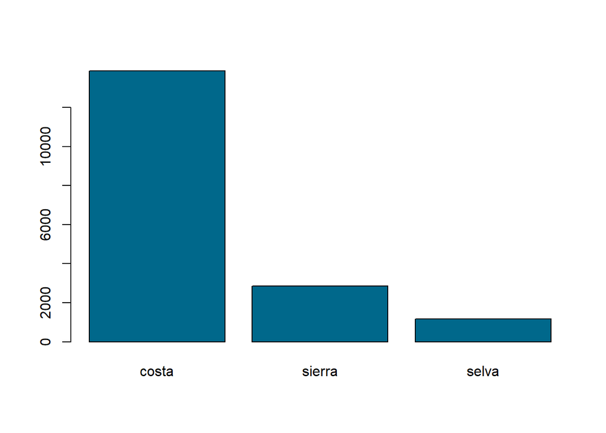

#### **Análisis de confiabilidad de los datos**

Es necesario recalcar que la data con la que se trabaja reúne la información de toda la población. Esta es conformada por todos los Colegios de Educación Especial en el Perú en el año 2015. En consecuencia, se presentará el análisis de confiabilidad para cierta muestra aleatoria de la población.

#### Funciones para el cálculo del tamaño de la muestra y estimación del intervalo de confianza

```r
# Para estimar el intervalo de confianza de una muestra no normal con varianza conocida
icv1 <- function(me, conf, var1, n){
  x1=me-qnorm(1-(1-conf)/2, mean=0, sd=1)*sqrt(var1/n)
  x2=me+qnorm(1-(1-conf)/2, mean=0, sd=1)*sqrt(var1/n)
  IC<-c(x1, x2)
  IC
}
```

```r
#Para calcular el tamaño de muestra
cn <- function(conf, desv, errorp){
  x1=(qnorm(1-(1-conf)/2, mean=0, sd=1)*desv/errorp)^2
  x1
}
```

Estas formulaciones fueron realizadas en base a lo presentado en las sesiones teóricas de la asignatura de Estadística y Probabilidades.

```r
costa<-Col_Espe %>% filter(Departamento=="Ancash"| Departamento=="Callao"| Departamento=="Ica"| Departamento=="Lima"| Departamento=="Piura"| Departamento=="La Libertad"|Departamento=="Arequipa"|Departamento=="Moquegua"|Departamento=="Tacna"|Departamento=="Lambayeque"| Departamento=="Tumbes"| Departamento=="Callao")
costa
```

| Código modular | Código de local | Nombre de IE | Nivel / Modalidad | Forma | Gestión / Dependencia | Dirección de IE | Departamento | Provincia | Distrito | Alumnos (2015) | Docentes (2015) | Secciones (2015) |
| --- | --- | --- | --- | --- | --- | --- | --- | --- | --- | --- | --- | --- |
| 0909721 | 015775 | SEÑOR DE LOS MILAGROS | Educación Especial | Escolarizado | Pública - Sector Educación | AVENIDA SIMON BOLIVAR S/N | Ancash | Huaraz | Huaraz | 57 | 20 | 11 |
| 0681726 | 026905 | SAN ANTONIO DE PADUA | Educación Especial | Escolarizado | Pública - Sector Educación | JIRON BOLOGNESI S/N | Ancash | Huaylas | Caraz | 22 | 3 | 7 |
| 1003151 | 037602 | CEBE AULA DE EDUCACION ESPECIAL 01 SANTA | Educación Especial | Escolarizado | Pública - Sector Educación | MZ W LOTE 1 | Ancash | Santa | Santa | 23 | 3 | 7 |
| 1000306 | 038041 | CEBE 03 | Educación Especial | Escolarizado | Pública - Sector Educación | JIRON 31 | Ancash | Santa | Nuevo Chimbote | 78 | 24 | 10 |
| 0570226 | 034793 | CEBE 01 | Educación Especial | Escolarizado | Pública - Sector Educación | MZ P LOTE 24-25 | Ancash | Santa | Chimbote | 123 | 36 | 11 |
| 0359323 | 035641 | CEBE FE Y ALEGRIA 42 | Educación Especial | Escolarizado | Pública - En convenio | AVENIDA JOSE PARDO 4071 MZ 13 LOTE 01 | Ancash | Santa | Chimbote | 145 | 41 | 17 |
| 1001627 | 529058 | PRITE LA VICTORIA | Educación Especial | No escolarizado | Pública - Sector Educación | MZ 6 LOTE 26-B ZONA II | Ancash | Santa | Chimbote | 84 | 9 | 5 |
| 0818518 | 022323 | 02 AGUSTIN EVANS | Educación Especial | Escolarizado | Pública - Sector Educación | CALLE MARISCAL SUCRE | Ancash | Casma | Casma | 16 | 7 | 8 |
| 1042399 | 026118 | 04 VIRGEN DEL ROSARIO | Educación Especial | Escolarizado | Pública - Sector Educación | CARRETERA PANAMERICANA NORTE KM.293 | Ancash | Huarmey | Huarmey | 47 | 7 | 12 |
| 0637330 | 072407 | CENTRO ESPECIAL MOLLENDO | Educación Especial | Escolarizado | Pública - Sector Educación | CALLE PUNO 710 | Arequipa | Islay | Mollendo | 41 | 10 | 11 |

[output cut: 279 more lines]

```r
sierra<-Col_Espe %>% filter(Departamento=="Huancavelica" | Departamento=="Apurimac"|Departamento=="Ayacucho"|Departamento=="Cusco"| Departamento=="Puno" | Departamento=="Junin" |Departamento=="Pasco" | Departamento=="Cajamarca" | Departamento=="Huanuco")
sierra
```

| Código modular | Código de local | Nombre de IE | Nivel / Modalidad | Forma | Gestión / Dependencia | Dirección de IE | Departamento | Provincia | Distrito | Alumnos (2015) | Docentes (2015) | Secciones (2015) |
| --- | --- | --- | --- | --- | --- | --- | --- | --- | --- | --- | --- | --- |
| 0576314 | 044914 | CEE ANDAHUAYLAS | Educación Especial | Escolarizado | Pública - Sector Educación | JIRON JUAN ANTONIO TRELLES 605 | Apurimac | Andahuaylas | Andahuaylas | 25 | 3 | 8 |
| 1088178 | 047540 | TALAVERA | Educación Especial | Escolarizado | Pública - Sector Educación | JIRON LIMA 242 | Apurimac | Andahuaylas | Talavera | 26 | 3 | 8 |
| 1205152 | 047007 | SAN JERONIMO | Educación Especial | Escolarizado | Pública - Sector Educación | JIRON ALFONSO UGARTE 700 | Apurimac | Andahuaylas | San Jeronimo | 18 | 2 | 5 |
| 0929554 | 055115 | 10 VILCABAMBA | Educación Especial | Escolarizado | Pública - Sector Educación | JAHUAPAMPA | Apurimac | Grau | Vilcabamba | 9 | 1 | 6 |
| 0929521 | 053951 | 04 CHUQUIBAMBILLA | Educación Especial | Escolarizado | Pública - Sector Educación | JIRON CHUQUIBAMBILLA S/N | Apurimac | Grau | Chuquibambilla | 6 | 1 | 4 |
| 0521971 | 074449 | SAN JUAN DE DIOS | Educación Especial | Escolarizado | Pública - Sector Educación | AVENIDA INDEPENDENCIA 461 | Ayacucho | Huamanga | Ayacucho | 74 | 10 | 11 |
| 1160068 | 509989 | PRITE I | Educación Especial | No escolarizado | Pública - Sector Educación | AVENIDA INDEPENDENCIA 461 | Ayacucho | Huamanga | Ayacucho | 32 | 5 | 5 |
| 1347558 | 560553 | EDUCACION ESPECIAL CANGALLO | Educación Especial | Escolarizado | Pública - Sector Educación | AVENIDA PEDRO C CARDENAS S/N | Ayacucho | Cangallo | Cangallo | 5 | 1 | 3 |
| 0670844 | 079946 | DIVINO NIÑO JESUS | Educación Especial | Escolarizado | Pública - Sector Educación | JIRON GERVACIO SANTILLANA 8VA CUADRA | Ayacucho | Huanta | Huanta | 34 | 6 | 8 |
| 1163153 | 080718 | LURICOCHA | Educación Especial | Escolarizado | Pública - Sector Educación | JIRON DELFINO LUDEÑA VEGA S/N | Ayacucho | Huanta | Luricocha | 47 | 3 | 8 |

[output cut: 132 more lines]

```r
selva<-Col_Espe %>% filter(Departamento=="Madre de Dios" | Departamento=="Ucayali" | Departamento=="Amazonas"|Departamento=="San Martin"|Departamento=="Loreto")
selva
```

| Código modular | Código de local | Nombre de IE | Nivel / Modalidad | Forma | Gestión / Dependencia | Dirección de IE | Departamento | Provincia | Distrito | Alumnos (2015) | Docentes (2015) | Secciones (2015) |
| --- | --- | --- | --- | --- | --- | --- | --- | --- | --- | --- | --- | --- |
| 0688333 | 394634 | STELLA MARIS | Educación Especial | Escolarizado | Pública - Sector Educación | JIRON MAQUEGUA CUADRA 11 | Madre de Dios | Tambopata | Tambopata | 47 | 10 | 8 |
| 0830760 | 495794 | REVERENDO PADRE SANTIAGO CASTRO LUCINI | Educación Especial | Escolarizado | Pública - Sector Educación | JIRON 28 DE JULIO 400 | Ucayali | Coronel Portillo | Calleria | 81 | 22 | 12 |
| 0922815 | 495119 | ESPECIAL 4 REFUGIO DE ESPERANZA | Educación Especial | Escolarizado | Pública - Sector Educación | AVENIDA LLOQUE YUPANQUI S/N | Ucayali | Coronel Portillo | Calleria | 117 | 41 | 16 |
| 1600485 | 813579 | PRITE MARIA GUADALUPE | Educación Especial | No escolarizado | Pública - Sector Educación | JIRON AGUAYTIA 605 | Ucayali | Coronel Portillo | Yarinacocha | 27 | 3 | 3 |
| 0666461 | 574927 | ATALAYA | Educación Especial | Escolarizado | Pública - Sector Educación | JIRON TENIENTE MEJIA S/N MZ 46-A LOTE 05 | Ucayali | Atalaya | Raymondi | 18 | 2 | 9 |
| 0666453 | 502539 | AGUAYTIA | Educación Especial | Escolarizado | Pública - Sector Educación | JIRON LAS ORQUIDEAS MZ 142 | Ucayali | Padre Abad | Padre Abad | 14 | 4 | 5 |
| 0478974 | 000062 | MONSEÑOR OCTAVIO ORTIZ ARRIETA | Educación Especial | Escolarizado | Pública - Sector Educación | AVENIDA SALAMANCA 495 | Amazonas | Chachapoyas | Chachapoyas | 24 | 8 | 12 |
| 0585505 | 002607 | 001 | Educación Especial | Escolarizado | Pública - Sector Educación | JIRON PIURA S/N | Amazonas | Bagua | Bagua | 28 | 10 | 8 |
| 1250323 | 002754 | NUESTRA SEÑORA DE GUADALUPE FE Y ALEGRIA 31 | Educación Especial | Escolarizado | Pública - En convenio | AVENIDA CAJAMARCA S/N | Amazonas | Bagua | La Peca | 7 | 2 | 4 |
| 0657346 | 008459 | POR LOS NIÑOS DE LUYA | Educación Especial | Escolarizado | Pública - Sector Educación | JIRON BLAS VALERA 451 | Amazonas | Luya | Luya | 3 | 1 | 2 |

[output cut: 32 more lines]

A continuación, procedemos a evaluar el tamaño de muestra considerando 3 niveles de confianza:

```
## [1] 205.29
```

```
## [1] 144.5859
```

```
## [1] 110.7424
```

```
## [1] 182.2442
```

```
## [1] 128.3548
```

```
## [1] 98.31051
```

```
## [1] 44.67614
```

```
## [1] 31.46545
```

```
## [1] 24.10027
```

```
## [1] 125.9866
```

```
## [1] 88.73252
```

```
## [1] 67.9627
```

```
## [1] 31.9134
```

```
## [1] 22.47664
```

```
## [1] 17.21549
```

```
## [1] 38.76117
```

```
## [1] 27.29953
```

```
## [1] 20.90947
```

```
## [1] 15.7425
```

```
## [1] 11.08746
```

```
## [1] 8.49219
```

```
## [1] 10.00181
```

```
## [1] 7.044284
```

```
## [1] 5.395413
```

```
## [1] 10.98508
```

```
## [1] 7.736802
```

```
## [1] 5.925831
```

#### **Por región**

##### **COSTA**

##### **Cálculo del intervalo de confianza para la media de docentes en la región costa**

Primeramente se organiza la información en un nuevo dataframe:

```r
DCosta<-Data %>% filter(Departamento=="Ancash"| Departamento=="Callao"| Departamento=="Ica"| Departamento=="Lima"| Departamento=="Piura"| Departamento=="La Libertad"|Departamento=="Arequipa"|Departamento=="Moquegua"|Departamento=="Tacna"|Departamento=="Lambayeque"| Departamento=="Tumbes"| Departamento=="Callao")
DCosta
```

| Código modular | Código de local | Nombre de IE | Nivel / Modalidad | Forma | Gestión / Dependencia | Dirección de IE | Departamento | Provincia | Distrito | Alumnos (2015) | Docentes (2015) | Secciones (2015) |
| --- | --- | --- | --- | --- | --- | --- | --- | --- | --- | --- | --- | --- |
| 0909721 | 015775 | SEÑOR DE LOS MILAGROS | Educación Especial | Escolarizado | Pública - Sector Educación | AVENIDA SIMON BOLIVAR S/N | Ancash | Huaraz | Huaraz | 57 | 20 | 11 |
| 0681726 | 026905 | SAN ANTONIO DE PADUA | Educación Especial | Escolarizado | Pública - Sector Educación | JIRON BOLOGNESI S/N | Ancash | Huaylas | Caraz | 22 | 3 | 7 |
| 1003151 | 037602 | CEBE AULA DE EDUCACION ESPECIAL 01 SANTA | Educación Especial | Escolarizado | Pública - Sector Educación | MZ W LOTE 1 | Ancash | Santa | Santa | 23 | 3 | 7 |
| 1000306 | 038041 | CEBE 03 | Educación Especial | Escolarizado | Pública - Sector Educación | JIRON 31 | Ancash | Santa | Nuevo Chimbote | 78 | 24 | 10 |
| 0570226 | 034793 | CEBE 01 | Educación Especial | Escolarizado | Pública - Sector Educación | MZ P LOTE 24-25 | Ancash | Santa | Chimbote | 123 | 36 | 11 |
| 0359323 | 035641 | CEBE FE Y ALEGRIA 42 | Educación Especial | Escolarizado | Pública - En convenio | AVENIDA JOSE PARDO 4071 MZ 13 LOTE 01 | Ancash | Santa | Chimbote | 145 | 41 | 17 |
| 1001627 | 529058 | PRITE LA VICTORIA | Educación Especial | No escolarizado | Pública - Sector Educación | MZ 6 LOTE 26-B ZONA II | Ancash | Santa | Chimbote | 84 | 9 | 5 |
| 0818518 | 022323 | 02 AGUSTIN EVANS | Educación Especial | Escolarizado | Pública - Sector Educación | CALLE MARISCAL SUCRE | Ancash | Casma | Casma | 16 | 7 | 8 |
| 1042399 | 026118 | 04 VIRGEN DEL ROSARIO | Educación Especial | Escolarizado | Pública - Sector Educación | CARRETERA PANAMERICANA NORTE KM.293 | Ancash | Huarmey | Huarmey | 47 | 7 | 12 |
| 0637330 | 072407 | CENTRO ESPECIAL MOLLENDO | Educación Especial | Escolarizado | Pública - Sector Educación | CALLE PUNO 710 | Arequipa | Islay | Mollendo | 41 | 10 | 11 |

[output cut: 279 more lines]

Se calcula entonces el tamaño de muestra deseado. En este caso y en los siguientes se prioriza tener un intervalo con una buena precisión hasta donde lo permita la población. En otras palabras, el número calculado no deberá sobrepasar al de la población. Por esta razón se escogió un error de 1.7

```r
cn(0.9, sd(DCosta$`Docentes (2015)`), 1.7)
```

```
## [1] 88.73252
```

Luego de ello se tomará una muestra aleatoria de la población y en base a ella se estimará el intervalo de confianza.

```r
MuestraCostaD <- sample(DCosta$`Docentes (2015)`, 89, replace = FALSE)
MuestraCostaD
```

```
##  [1] 23 18  2 15  6  5  3  4  1 25  5  4  7  4 36 23 26  4  6  3 14 12 12  3 14
## [26] 17  6 22  5  5  3  1  7 14  1 17  6  6 17  3 22  1 16 19  1 18 28 23  5  6
## [51] 19 12  3  1  1  1 26  2  5  5  5 20  3  5  9  2  1 16 45  2  8  2  1  1  2
## [76]  4 34 13 13  3 10  5 12 15  7  3 14 54  1
```

Intervalo de confianza:

```
## [1]  8.740759 12.135646
```

A continuación se muestra la distribución de la población y se compara la media real con la media estimada.

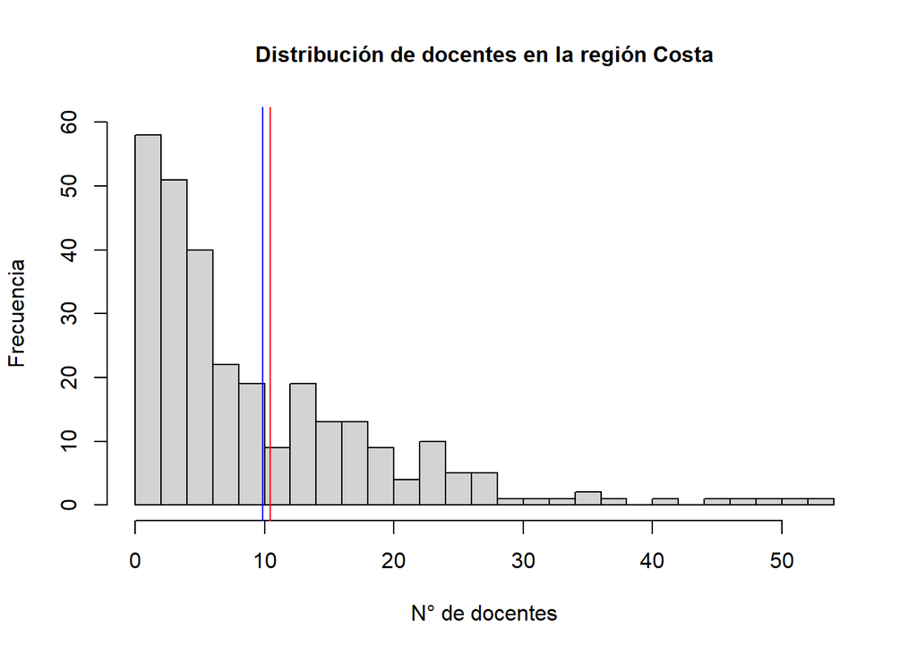

Se define la siguiente función para indicar el rechazo o aceptación de la hipótesis nula:

```r
# Para varianza conocida
hipvarcon <- function(media.mues, mu, varia, signifi, n, alt){
  if(alt=="doble"){
    es=qnorm(signifi/2)
    as=qnorm(1-signifi/2)
    z=(media.mues-mu)*sqrt(n/varia)
    if(z>es && z<as)
      return("La H0 cumple, no se rechaza")
    else
      return("La H0 no cumple, se rechaza")
    }
  else if(alt=="izquierda"){
    es=qnorm(signifi)
    z=(media.mues-mu)*sqrt(n/varia)
    if(z>es)
      return("La H0 cumple, no se rechaza")
    else
      return("La H0 no cumple, se rechaza")
    }
  else if(alt=="derecha"){
    es=qnorm(1-signifi)
    z=(media.mues-mu)*sqrt(n/varia)
    if(z<es)
      return("La H0 cumple, no se rechaza")
    else
      return("La H0 no cumple, se rechaza")
    }
  else
    return("error")
}
```

Compararemos lo que nos dice la prueba de hipótesis con la respuesta obtenida directamente de la población. En esta ocasión se propone lo siguiente:

```r
mean(DCosta$`Docentes (2015)`)
```

```
## [1] 9.885813
```

Ya que se conoce la media de la población, veremos si la prueba de hipótesis coordina con este resultado:

H0 = La media de la población de docentes en la región costa es mayor o igual a 9

```r
hipvarcon(media.mues=mean(MuestraCostaD), mu=9, varia=var(DCosta$`Docentes (2015)`), signifi=0.05, n=89, alt="izquierda")
```

```
## [1] "La H0 cumple, no se rechaza"
```

Como podemos observar, la H0 se cumple. La media de docentes en la región costa es superior a 9.

##### **Cálculo del intervalo de confianza para la media de alumnos en la región costa**

En el caso de los alumnos, el error que se tomó fue de 6 debido a la gran diferencia de valores entre las distintas instituciones a lo largo de esta región.

```r
cn(0.9, sd(DCosta$`Alumnos (2015)`), 6)
```

```
## [1] 144.5859
```

```r
MuestraCostaAl <- sample(DCosta$`Alumnos (2015)`, 145, replace = FALSE)
MuestraCostaAl
```

```
##   [1]   6   2  64  15   9  25  21  60  95  21  64  41  40  40   3  10  15  23
##  [19]  16  17  74  27  17  79 118  17  17  60  22  15 123  28  30  43  42  28
##  [37]  31  75  13 132  38  39  28  59  21 118  15  41  36  20  37 129  25   6
##  [55]  27   1  16  30 103  17  35  21  21  42  17  24  71  79  13  31  84  34
##  [73]  95  15  55  24  32  30  45   7 116  86  29  57  20   9  85  36   8 120
##  [91]  22  42  56   4   6  25 133  97   7  20  80  39  37  32  24   8  14  24
## [109]  34  42  47  30  10  16  43  65  63 106  37  13  11  32  30  79  21  20
## [127]  83  18  17  96  64  17  12  16  32  45   6  45  27  65   8 103  91  28
## [145] 107
```

Intervalo de confianza:

```
## [1] 35.20857 47.19143
```

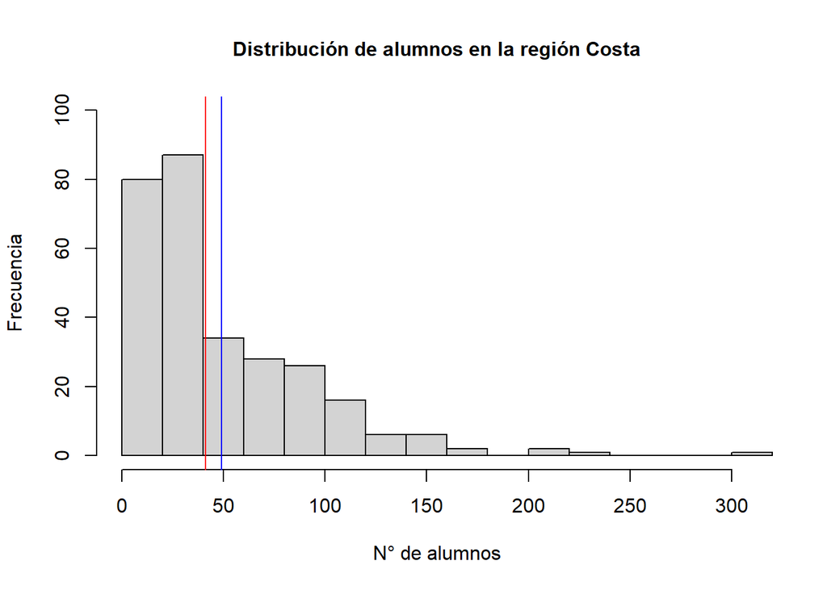

Compararemos lo que nos dice la prueba de hipótesis con la respuesta obtenida directamente de la población. En esta ocasión se propone lo siguiente:

```r
mean(DCosta$`Alumnos (2015)`)
```

```
## [1] 48.95502
```

Ya que se conoce la media de la población, veremos si la prueba de hipótesis coordina con este resultado:

H0 = La media de la población de alumnos en la región costa es mayor o igual a 45

```r
hipvarcon(media.mues=mean(MuestraCostaAl), mu=45, varia=var(DCosta$`Alumnos (2015)`), signifi=0.05, n=145, alt="izquierda")
```

```
## [1] "La H0 cumple, no se rechaza"
```

Como podemos observar la H0 se cumple. La media de alumnos en la región costa es superior a 45.

##### **SIERRA**

##### **Cálculo del intervalo de confianza para la media de docentes en la región Sierra**

```r
DSierra<-Data %>% filter(Departamento=="Huancavelica" | Departamento=="Apurimac"|Departamento=="Ayacucho"|Departamento=="Cusco"| Departamento=="Puno" | Departamento=="Junin" |Departamento=="Pasco" | Departamento=="Cajamarca" | Departamento=="Huanuco")
DSierra
```

| Código modular | Código de local | Nombre de IE | Nivel / Modalidad | Forma | Gestión / Dependencia | Dirección de IE | Departamento | Provincia | Distrito | Alumnos (2015) | Docentes (2015) | Secciones (2015) |
| --- | --- | --- | --- | --- | --- | --- | --- | --- | --- | --- | --- | --- |
| 0576314 | 044914 | CEE ANDAHUAYLAS | Educación Especial | Escolarizado | Pública - Sector Educación | JIRON JUAN ANTONIO TRELLES 605 | Apurimac | Andahuaylas | Andahuaylas | 25 | 3 | 8 |
| 1088178 | 047540 | TALAVERA | Educación Especial | Escolarizado | Pública - Sector Educación | JIRON LIMA 242 | Apurimac | Andahuaylas | Talavera | 26 | 3 | 8 |
| 1205152 | 047007 | SAN JERONIMO | Educación Especial | Escolarizado | Pública - Sector Educación | JIRON ALFONSO UGARTE 700 | Apurimac | Andahuaylas | San Jeronimo | 18 | 2 | 5 |
| 0929554 | 055115 | 10 VILCABAMBA | Educación Especial | Escolarizado | Pública - Sector Educación | JAHUAPAMPA | Apurimac | Grau | Vilcabamba | 9 | 1 | 6 |
| 0929521 | 053951 | 04 CHUQUIBAMBILLA | Educación Especial | Escolarizado | Pública - Sector Educación | JIRON CHUQUIBAMBILLA S/N | Apurimac | Grau | Chuquibambilla | 6 | 1 | 4 |
| 0521971 | 074449 | SAN JUAN DE DIOS | Educación Especial | Escolarizado | Pública - Sector Educación | AVENIDA INDEPENDENCIA 461 | Ayacucho | Huamanga | Ayacucho | 74 | 10 | 11 |
| 1160068 | 509989 | PRITE I | Educación Especial | No escolarizado | Pública - Sector Educación | AVENIDA INDEPENDENCIA 461 | Ayacucho | Huamanga | Ayacucho | 32 | 5 | 5 |
| 1347558 | 560553 | EDUCACION ESPECIAL CANGALLO | Educación Especial | Escolarizado | Pública - Sector Educación | AVENIDA PEDRO C CARDENAS S/N | Ayacucho | Cangallo | Cangallo | 5 | 1 | 3 |
| 0670844 | 079946 | DIVINO NIÑO JESUS | Educación Especial | Escolarizado | Pública - Sector Educación | JIRON GERVACIO SANTILLANA 8VA CUADRA | Ayacucho | Huanta | Huanta | 34 | 6 | 8 |
| 1163153 | 080718 | LURICOCHA | Educación Especial | Escolarizado | Pública - Sector Educación | JIRON DELFINO LUDEÑA VEGA S/N | Ayacucho | Huanta | Luricocha | 47 | 3 | 8 |

[output cut: 132 more lines]

Se tomó un error de 1.7, ya que el tamaño de muestra que nos resultaba era bastante menor al tamaño poblacional. De esta manera se podía obtener una mayor precisión en el resultado.

```r
cn(0.9, sd(DSierra$`Docentes (2015)`), 1.7)
```

```
## [1] 22.47664
```

```r
MuestraSierraD <- sample(DSierra$`Docentes (2015)`, 23, replace = FALSE)
MuestraSierraD
```

```
##  [1]  8  1  2  4  1  1  1  2  4  5  9  3  3  9 12  5  3  1  6  2  6  6  1
```

Intervalo de confianza:

```
## [1] 2.449887 5.810982
```

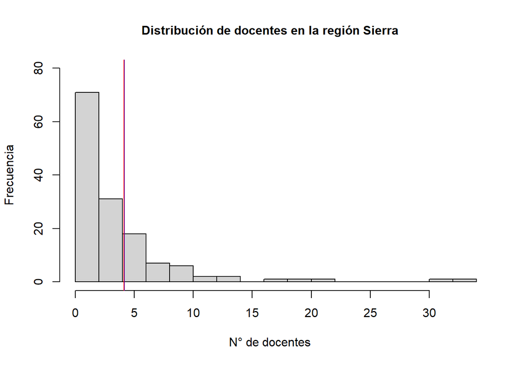

Compararemos lo que nos dice la prueba de hipótesis con la respuesta obtenida directamente de la población. En esta ocasión se propone lo siguiente:

```r
mean(DSierra$`Docentes (2015)`)
```

```
## [1] 4.161972
```

Ya que se conoce la media de la población, veremos si la prueba de hipótesis coordina con este resultado:

H0 = La media de la población de docentes en la región sierra es mayor o igual a 3

```r
hipvarcon(media.mues=mean(MuestraSierraD), mu=3, varia=var(DSierra$`Docentes (2015)`), signifi=0.05, n=23, alt="izquierda")
```

```
## [1] "La H0 cumple, no se rechaza"
```

Como podemos observar, la H0 se cumple. La media de docentes en la región sierra es superior a 3.

##### **Cálculo del intervalo de confianza para la media de alumnos en la región Sierra**

El error que se consideró es de 3.5, debido a que para esta variable sí existía mayor variación respecto a los resultados. Por lo tanto, el tamaño muestral requerido era mayor.

```r
cn(0.9, sd(DSierra$`Alumnos (2015)`), 3.5)
```

```
## [1] 128.3548
```

```r
MuestraSierraAl <- sample(DSierra$`Alumnos (2015)`, 129, replace = FALSE)
MuestraSierraAl
```

```
##   [1]  17   9  40  13  23   6  35  21   4  20  14   7  10  46  38  10  15  14
##  [19]  12   2  20  16  23  50   8  62   6   9  26  18  18  25   7  10  23   9
##  [37]  37   7   7  23  16  52   6  35  14  14  19  36   5  22  10  14   9   6
##  [55]  26  42   4  14  10   5  17  85  18  10  11  11   5   1  21   6  10  17
##  [73]  14  14  46   5   3  44  18  20  22  11   5  14  17  47   8   7   7  22
##  [91]   6  16   7  32  34  87  26  12   2 209  34  10  13  25  33  65   6   7
## [109]  67  25   8  74  81   2  17  15  17  35  14   2   4  29  34  15  71   1
## [127]  33   8   8
```

Intervalo de confianza:

```
## [1] 18.51652 25.49899
```

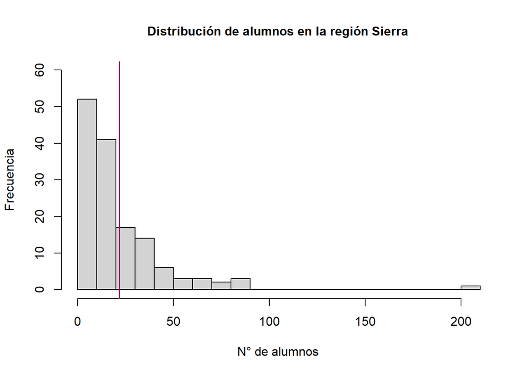

Compararemos lo que nos dice la prueba de hipótesis con la respuesta obtenida directamente de la población. En esta ocasión se propone lo siguiente:

```r
mean(DSierra$`Alumnos (2015)`)
```

```
## [1] 21.85915
```

Ya que se conoce la media de la población, veremos si la prueba de hipótesis coordina con este resultado:

H0 = La media de la población de alumnos en la región sierra es mayor o igual a 18

```r
hipvarcon(media.mues=mean(MuestraSierraAl), mu=18, varia=var(DSierra$`Alumnos (2015)`), signifi=0.05, n=129, alt="izquierda")
```

```
## [1] "La H0 cumple, no se rechaza"
```

Como podemos observar, la H0 se cumple. La media de alumnos en la región sierra es superior a 18.

##### **SELVA**

##### **Cálculo del intervalo de confianza para la media de docentes en la región Selva**

```r
DSelva<-Data %>% filter(Departamento=="Madre de Dios" | Departamento=="Ucayali" | Departamento=="Amazonas"|Departamento=="San Martin"|Departamento=="Loreto")
DSelva
```

| Código modular | Código de local | Nombre de IE | Nivel / Modalidad | Forma | Gestión / Dependencia | Dirección de IE | Departamento | Provincia | Distrito | Alumnos (2015) | Docentes (2015) | Secciones (2015) |
| --- | --- | --- | --- | --- | --- | --- | --- | --- | --- | --- | --- | --- |
| 0688333 | 394634 | STELLA MARIS | Educación Especial | Escolarizado | Pública - Sector Educación | JIRON MAQUEGUA CUADRA 11 | Madre de Dios | Tambopata | Tambopata | 47 | 10 | 8 |
| 0830760 | 495794 | REVERENDO PADRE SANTIAGO CASTRO LUCINI | Educación Especial | Escolarizado | Pública - Sector Educación | JIRON 28 DE JULIO 400 | Ucayali | Coronel Portillo | Calleria | 81 | 22 | 12 |
| 0922815 | 495119 | ESPECIAL 4 REFUGIO DE ESPERANZA | Educación Especial | Escolarizado | Pública - Sector Educación | AVENIDA LLOQUE YUPANQUI S/N | Ucayali | Coronel Portillo | Calleria | 117 | 41 | 16 |
| 1600485 | 813579 | PRITE MARIA GUADALUPE | Educación Especial | No escolarizado | Pública - Sector Educación | JIRON AGUAYTIA 605 | Ucayali | Coronel Portillo | Yarinacocha | 27 | 3 | 3 |
| 0666461 | 574927 | ATALAYA | Educación Especial | Escolarizado | Pública - Sector Educación | JIRON TENIENTE MEJIA S/N MZ 46-A LOTE 05 | Ucayali | Atalaya | Raymondi | 18 | 2 | 9 |
| 0666453 | 502539 | AGUAYTIA | Educación Especial | Escolarizado | Pública - Sector Educación | JIRON LAS ORQUIDEAS MZ 142 | Ucayali | Padre Abad | Padre Abad | 14 | 4 | 5 |
| 0478974 | 000062 | MONSEÑOR OCTAVIO ORTIZ ARRIETA | Educación Especial | Escolarizado | Pública - Sector Educación | AVENIDA SALAMANCA 495 | Amazonas | Chachapoyas | Chachapoyas | 24 | 8 | 12 |
| 0585505 | 002607 | 001 | Educación Especial | Escolarizado | Pública - Sector Educación | JIRON PIURA S/N | Amazonas | Bagua | Bagua | 28 | 10 | 8 |
| 1250323 | 002754 | NUESTRA SEÑORA DE GUADALUPE FE Y ALEGRIA 31 | Educación Especial | Escolarizado | Pública - En convenio | AVENIDA CAJAMARCA S/N | Amazonas | Bagua | La Peca | 7 | 2 | 4 |
| 0657346 | 008459 | POR LOS NIÑOS DE LUYA | Educación Especial | Escolarizado | Pública - Sector Educación | JIRON BLAS VALERA 451 | Amazonas | Luya | Luya | 3 | 1 | 2 |

[output cut: 32 more lines]

Para el presente caso, el error tomado es de 2.5, ya que al no haber tantas instituciones educativas y una variación considerable entre ellas, se requería un mayor error para obtener un tamaño muestral equilibrado con las consideraciones mencionadas.

```r
cn(0.9, sd(DSelva$`Docentes (2015)`), 2.5)
```

```
## [1] 27.29953
```

```r
MuestraSelvaD <- sample(DSelva$`Docentes (2015)`, 28, replace = FALSE)
MuestraSelvaD
```

```
##  [1]  2  2  4 10  8  6 14 41  4  2  3  6  2  3 24  1  6  3 10 23  2  3  1  4  3
## [26]  1 10  5
```

Intervalo de confianza:

```
## [1] 4.781469 9.718531
```

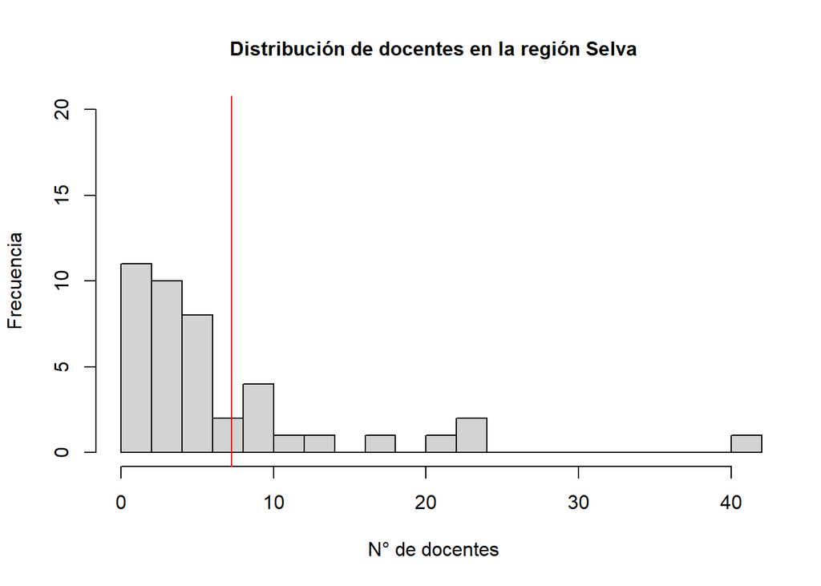

Compararemos lo que nos dice la prueba de hipótesis con la respuesta obtenida directamente de la población. En esta ocasión se propone lo siguiente:

```r
mean(DSelva$`Docentes (2015)`)
```

```
## [1] 7.238095
```

Ya que se conoce la media de la población, veremos si la prueba de hipótesis coordina con este resultado:

H0 = La media de la población de docentes en la región selva es menor o igual a 10

```r
hipvarcon(media.mues=mean(MuestraSelvaD), mu=10, varia=var(DSelva$`Docentes (2015)`), signifi=0.05, n=128, alt="derecha")
```

```
## [1] "La H0 cumple, no se rechaza"
```

Como podemos observar, la H0 se cumple. La media de docentes en la región selva es inferior a 10.

##### **Cálculo del intervalo de confianza para la media de alumnos en la región Selva**

Similar al caso anterior, se contó con un tamaño poblacional pequeño, junto con una mayor variación con la población de alumnos. Por estos motivos, se escogió el valor del error de 10.

```r
cn(0.9, sd(DSelva$`Alumnos (2015)`), 10)
```

```
## [1] 31.46545
```

```r
MuestraSelvaAl <- sample(DSelva$`Alumnos (2015)`, 32, replace = FALSE)
MuestraSelvaAl
```

```
##  [1]  39  15  53  47  24  27   3  18  11  11   8   7  17  24  39  38  10  53  14
## [20] 102  18  47  28  17 117  23   9  32  81  16  42  28
```

Intervalo de confianza:

```
## [1] 21.89637 41.72863
```

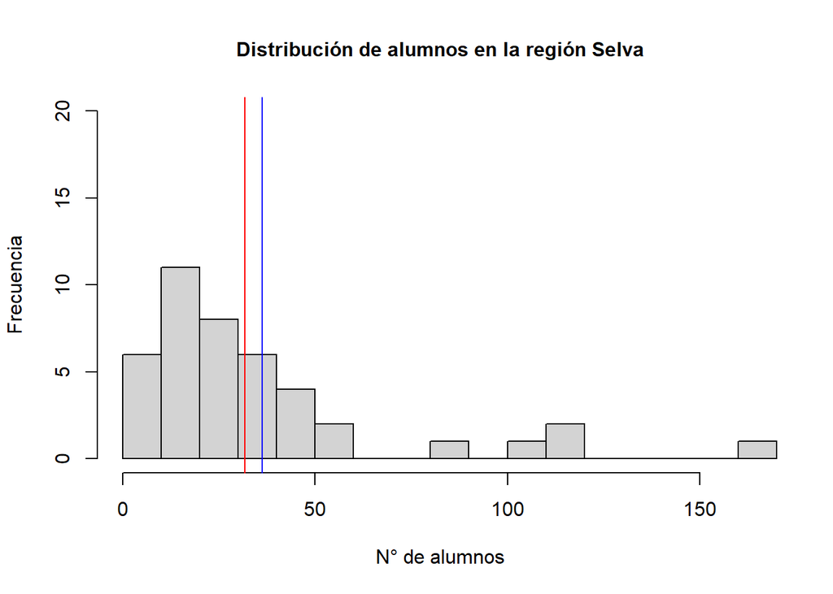

Compararemos lo que nos dice la prueba de hipótesis con la respuesta obtenida directamente de la población, en esta ocasión se propone lo siguiente:

```r
mean(DSelva$`Alumnos (2015)`)
```

```
## [1] 36.30952
```

Ya que se conoce la media de la población, veremos si la prueba de hipótesis coordina con este resultado:

H0 = La media de la población de alumnos en la región selva es menor o igual a 40

```r
hipvarcon(media.mues=mean(MuestraSelvaAl), mu=40, varia=var(DSelva$`Alumnos (2015)`), signifi=0.05, n=128, alt="derecha")
```

```
## [1] "La H0 cumple, no se rechaza"
```

Como podemos observar, la H0 se cumple. La media de alumnos en la región selva es inferior a 40.

##### **Intervalo de confianza para la capital Lima**

##### **Cálculo del intervalo de confianza para la media de alumnos en Lima**

```r
DLima<-Data %>% filter(Departamento=='Lima')
DLima
```

| Código modular | Código de local | Nombre de IE | Nivel / Modalidad | Forma | Gestión / Dependencia | Dirección de IE | Departamento | Provincia | Distrito | Alumnos (2015) | Docentes (2015) | Secciones (2015) |
| --- | --- | --- | --- | --- | --- | --- | --- | --- | --- | --- | --- | --- |
| 0600023 | 353600 | 003 DIVINO JESUS | Educación Especial | Escolarizado | Pública - Sector Educación | CALLE FRANCIA S/N | Lima | Cañete | Mala | 40 | 10 | 10 |
| 0599878 | 353054 | 04 | Educación Especial | Escolarizado | Pública - Sector Educación | JIRON HUANCAYO CDRA. 7 | Lima | Cañete | Imperial | 74 | 12 | 11 |
| 0702290 | 522453 | ESPECIAL CHILCA | Educación Especial | Escolarizado | Pública - Sector Educación | JIRON PUNO S/N | Lima | Cañete | Chilca | 20 | 2 | 7 |
| 0523027 | 359107 | 01 SAN JUDAS TADEO | Educación Especial | Escolarizado | Pública - Sector Educación | CALLE MARIN S/N | Lima | Huaura | Huacho | 41 | 20 | 11 |
| 1020262 | 508598 | 02 SAN FRANCISCO DE ASIS | Educación Especial | Escolarizado | Pública - Sector Educación | CALLE 5 S/N | Lima | Huaura | Huaura | 61 | 24 | 11 |
| 0702332 | 361054 | 03 | Educación Especial | Escolarizado | Pública - Sector Educación | CALLE LOS EMPLEADOS S/N | Lima | Huaura | Sayan | 34 | 13 | 10 |
| 1519453 | 732413 | SANTA ROSA DE LOS HUACOS | Educación Especial | Escolarizado | Privada - Parroquial | CALLE PEDRO REYES SUAREZ S/N | Lima | Huaura | Hualmay | 30 | 7 | 10 |
| 1519958 | 732615 | PRITE VIRGEN MARIA | Educación Especial | No escolarizado | Pública - Sector Educación | CALLE 30 DE AGOSTO S/N MZ C LOTE 24 ETAPA II | Lima | Huaura | Huacho | 63 | 6 | 8 |
| 1076918 | 736067 | ESPECIAL CANTA | Educación Especial | Escolarizado | Pública - Sector Educación | JIRON INDEPENDENCIA S/N | Lima | Canta | Canta | 25 | 3 | 5 |
| 0751024 | 736487 | YAUYOS | Educación Especial | Escolarizado | Pública - Sector Educación | CALLE JORGE CHAVEZ 306 | Lima | Yauyos | Yauyos | 6 | 1 | 3 |

[output cut: 113 more lines]

Se propuso un valor de error de 8, ya que si bien la población era ciertamente grande, la desviación estándar también era considerable.

```r
cn(0.9, sd(DLima$`Alumnos (2015)`), 8)
```

```
## [1] 106.3005
```

```r
MuestraLimaA <- sample(DLima$`Alumnos (2015)`, 107, replace = FALSE)
MuestraLimaA
```

```
##   [1]  41  28  42 124  99 108  20 310  24  73 120 118  43   2  91  69  89 132
##  [19]   7  79  68  31  24 101  62  32  23  81  31  33  80  97  95 203  78  73
##  [37]  64  56   4 155  65  40  20  51  37 146   6  84  30  37  84  17  59  85
##  [55] 109 116  60  30  79  30  15  60  20  98   6 133  83 103  27  99 124   2
##  [73]  41  65  74 107  27 173 100 216 118  24  30  20  44  34  75 129 141  83
##  [91]  45  30  42  65 103   3  95  92  39  25  91  63  26  14  41  30  45
```

Intervalo de confianza:

```r
icv1(mean(MuestraLimaA), 0.9, var(DLima$`Alumnos (2015)`), 107)
```

```
## [1] 60.39068 76.33829
```

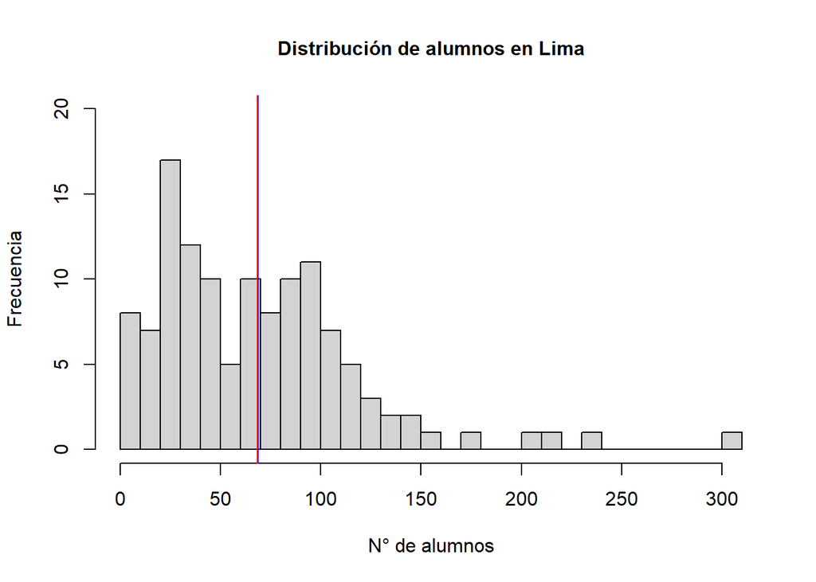

Compararemos lo que nos dice la prueba de hipótesis con la respuesta obtenida directamente de la población. En esta ocasión se propone lo siguiente:

```r
mean(DLima$`Alumnos (2015)`)
```

```
## [1] 68.70732
```

Ya que se conoce la media de la población, veremos si la prueba de hipótesis coordina con este resultado:

H0 = La media de la población de alumnos en Lima es menor o igual a 80

```r
hipvarcon(media.mues=mean(MuestraLimaA), mu=80, varia=var(DLima$`Alumnos (2015)`), signifi=0.05, n=107, alt="derecha")
```

```
## [1] "La H0 cumple, no se rechaza"
```

Como podemos observar, la H0 se cumple. La media de alumnos en Lima es inferior a 80.

##### **Cálculo del intervalo de confianza para la media de docentes en Lima**

Para los docentes de Lima vemos que el error es mucho menor en comparación al de los alumnos. Esto se debe principalmente a la desviación estándar de esta población, la cual es mucho menor.

```r
cn(0.9, sd(DLima$`Docentes (2015)`), 1.8)
```

```
## [1] 93.38551
```

```r
MuestraLimaD <- sample(DLima$`Docentes (2015)`, 94, replace = FALSE)
MuestraLimaD
```

```
##  [1]  8  3 14 11 17 21 12  5  8  8 24 22 27 34 27 25 11 31  4  6  7 25 20 10 18
## [26]  5 23 17  4  3 18  1  5 14 17  1  3  7 12  5 24  6 12 14 17 52  3 26 20 18
## [51] 14 13  8  6  1  1  5  7 50  6 19 37 26  3  3 27  7 18  5 12 19  5  5 27 15
## [76] 20  5 12 26  4 28  5  3 23  4 22  1 23  6  6  5 23 23  7
```

Intervalo de confianza:

```
## [1] 12.14206 15.73028
```

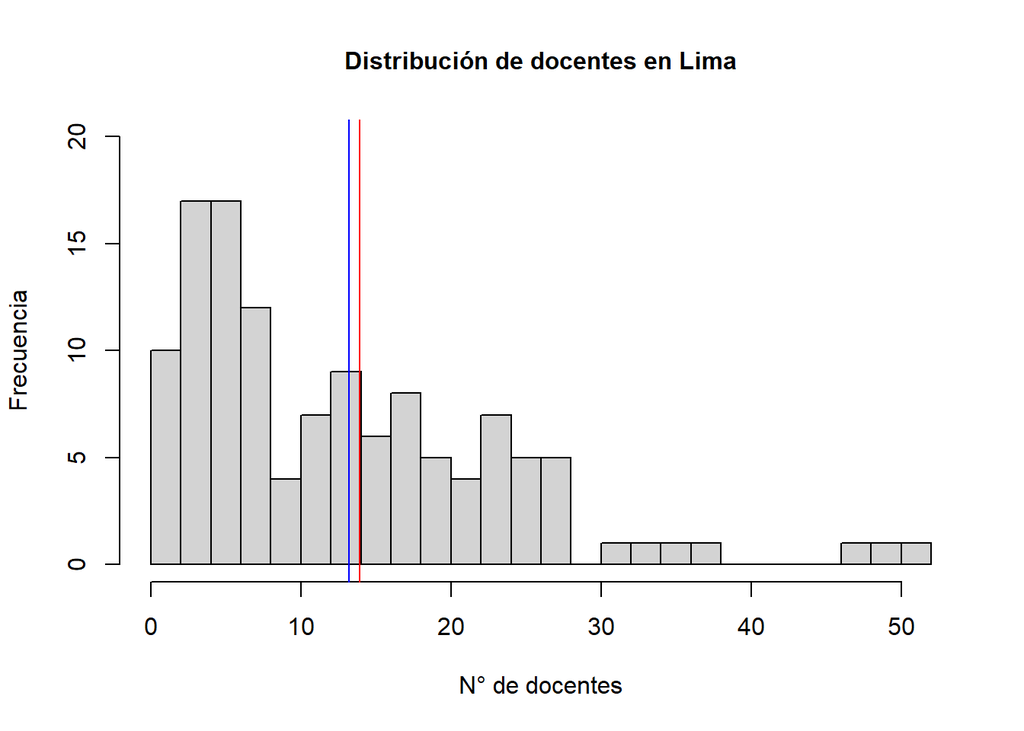

Compararemos lo que nos dice la prueba de hipótesis con la respuesta obtenida directamente de la población. En esta ocasión se propone lo siguiente:

```r
mean(DLima$`Docentes (2015)`)
```

```
## [1] 13.22764
```

Ya que se conoce la media de la población, veremos si la prueba de hipótesis coordina con este resultado:

H0 = La media de la población de docentes en Lima es menor o igual a 20

```r
hipvarcon(media.mues=mean(MuestraLimaD), mu=20, varia=var(DLima$`Docentes (2015)`), signifi=0.05, n=94, alt="derecha")
```

```
## [1] "La H0 cumple, no se rechaza"
```

Como podemos observar, la H0 se cumple.La media de docentes en Lima es inferior a 20.

##### **Para Perú**

##### **Cálculo del intervalo de confianza para la media de alumnos en Perú**

Se toma un error de 3.2 debido a las observaciones atípicas de la población (las que causan una variación de los datos muy alta). Se interpreta que esto se debe a la pronunciada centralización presente en el país.

```r
cn(0.9, sd(Data$`Alumnos (2015)`), 3.2)
```

```
## [1] 422.1443
```

```r
MuestraPeruA<- sample(Data$`Alumnos (2015)`, 423, replace = FALSE)
MuestraPeruA
```

```
##   [1]  64  20  10  28  84  15  45   9  79  86  24  78  14  20  45  15  29  83
##  [19]  22   5  25   1  11   7  16  42   8   6  26  24  14  17   8  18   6  52
##  [37]  28  65  55   9  11  11 157  37  71  32  30   9   6  41  27  10  16  17
##  [55]   5  41  33  26   5  23   6  25  25  23  37  15  17  11  40  86  45   4
##  [73]  34   3  21  69  84  27 100  46  26   7  13 129  15  38  41  45  23  38
##  [91]  32  16 203  25  43  14  73  40  23   6  42  41   4  95  25  12  37  11
## [109]  34  62   5   7 116  47  38  82  12  79  65   8  47  24  20  61   2  18
## [127]  36 119  42   3  59  78  45 118 145  17  17 157  25  21  14  47  32   9
## [145]  17  13  62  13 146  71 109  57   6  67  26  16 155   6   4  10   7  44
## [163] 124  89  32  14   5   4  44  18  37  21  99  42  16   4   8   8  33  34
## [181]  17 118 103  43   7  17   6  21  24  14  23  20  45  27  35  30   1  73
## [199]  53  34  85   6  32  51 173  40  16  28 216  40  15  87  14  11  18  16
## [217]  23  39  31  15  41  20  10  24   1  11  80  40   7  30  17   6  92  33
## [235]  30  99 117   4  17 123  23  30  18  15 101 133   9  10  20  17  35  10
## [253]  15  14  13 103  85  17  60  21  65  10  10  97  38  13  80  73  34  17
## [271]  18  28 102  60  17  30   6  65  24  12   2  20  22  91   2  11  33  35
## [289]  20  74  10  80   8  21 107  26  74  10  84   1   3  95  28  31  24 112
## [307]  15 209 310  83  21  14  81  46   9  56  15  47  33 132  17   3  53  42
## [325]  13  20  25  33  35  60   8 102  25   9   7  28  16  18  20  85  47   7
## [343]  63 106  21  33  13  68   6 234  98  16  60  14  15  37   5  22   2 167
## [361]  39  21  25  36 165   7   7  14   9   7  10  17 108  24  53  37  24   9
## [379]  37   2  31  57  52  12  17   8  38 107  63  65  25  64   7  35  36  17
## [397]  18 117  30  17   2  19  11  27  14 115  30  91  47   4  32  14   7  84
## [415]  10   7  27  24  12  32   6 124  10
```

Intervalo de confianza:

```
## [1] 36.54083 42.93435
```

Intervalo de confianza con una muestra inferior a 30:

```r
x <- sample(DCosta$`Alumnos (2015)`, 25, replace = FALSE)
t.test(x, conf.level=0.9)
```

```
##
##  One Sample t-test
##
## data:  x
## t = 5.1514, df = 24, p-value = 2.834e-05
## alternative hypothesis: true mean is not equal to 0
## 90 percent confidence interval:
##  41.83586 83.44414
## sample estimates:
## mean of x
##     62.64
```

Se puede observar que en esta última situación se pierde precisión, lo que amplia mucho más el intervalo de confianza. Además, como la variable “Alumnos” podría variar según la región en la que se evalúe, esto podría afectar mucho al calculo realizado. Debido a lo mencionado, se sugiere tomar una muestra representativa mucho mayor para estimar un intervalo de confianza adecuado.

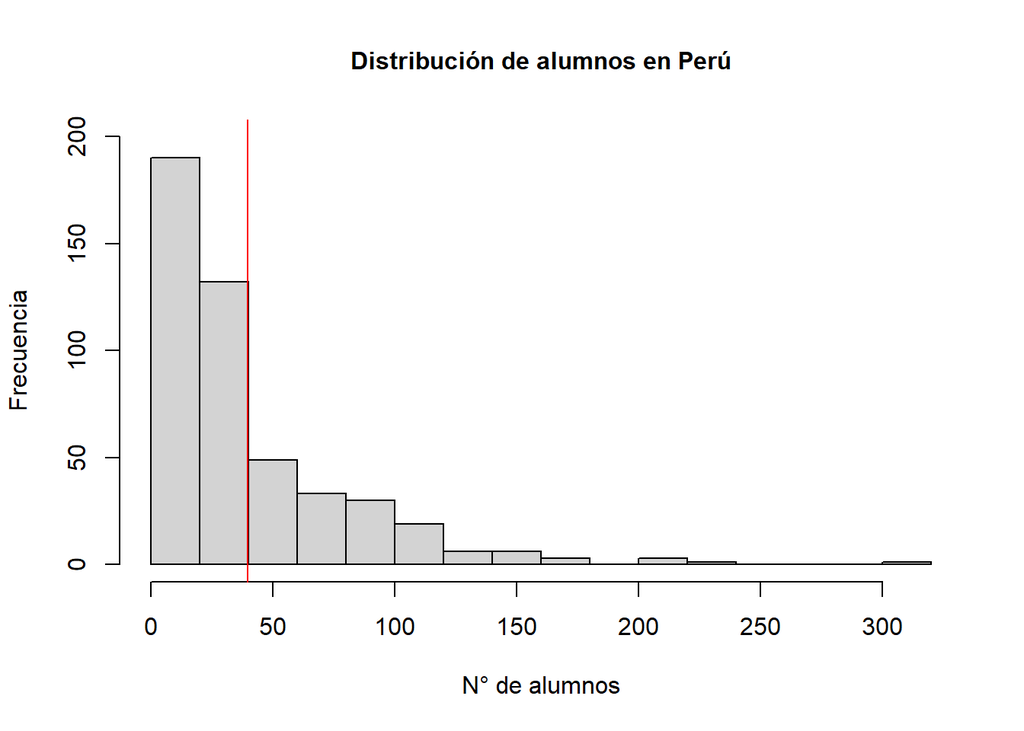

Compararemos lo que nos dice la prueba de hipótesis con la respuesta obtenida directamente de la población. En esta ocasión se propone lo siguiente:

```r
mean(Data$`Alumnos (2015)`)
```

```
## [1] 39.69767
```

Ya que se conoce la media de la población, veremos si la prueba de hipótesis coordina con este resultado:

H0 = La media de la población de alumnos en el Perú es mayor o igual a 45

```r
hipvarcon(media.mues=mean(MuestraPeruA), mu=45, varia=var(Data$`Alumnos (2015)`), signifi=0.05, n=423, alt="izquierda")
```

```
## [1] "La H0 no cumple, se rechaza"
```

Como podemos observar, la H0 no se cumple. Esto quiere decir que la media de alumnos debería ser menor a 45, lo cual es cierto.

##### **Cálculo del intervalo de confianza para la media de docentes en Perú**

Aqui el error es 0.7 debido a que la concentración de los datos es mucho mejor que para el caso de alumnos.

```r
cn(0.9, sd(Data$`Docentes (2015)`), 0.7)
```

```
## [1] 425.927
```

```r
MuestraPeruD <- sample(Data$`Docentes (2015)`, 426, replace = FALSE)
MuestraPeruD
```

```
##   [1]  3 10  5 16  5  4  3 21 24 14  9 10  1 10 17  3  3 15 20  8  2  4  2  9  2
##  [26] 16  7  1  3  1  2  7  2  1  2 12 50  4 13  6  5  7 27  8  3  1  5  6 18  5
##  [51]  3  1  2 27 22  2  2 18 14  5  5  3 20  9 10  1  3  5  9  8  1  3  5  1  1
##  [76]  1  8  9  2  3  4 24  1  5  3 31 15  5 18  4  2  5  2 10  7  2  1  7 20  1
## [101] 26 23  2  2  2  6  3 19  4  4 11  3  2 16  2 13  2  3  8  5  7  2  2 16  3
## [126] 24 14  2  4  8 33  1  9 11 17  1 18 13 15  3  2  2  1  5 31 54  6  4  1  3
## [151] 28 19  2 10  8  3 52  3 37  4 26 20  3  3  1  4 10  1  9  3 22  4  3 14  4
## [176] 26  3  5  2 23 17  5  1  7 12  3  2 21 13  3 23 41  1  9  6 18 11  1  6  9
## [201]  6  2  2  5 16 23  2  3 25  3  6  2  2  7 15 10 19 18  1 25  2  4 13  1  6
## [226] 10  3  1  5  4 48  1  1  6  6  4  1  3 14 12  3 14  2  1  6  1  1  2  8  3
## [251] 27  9  5  6  1  1  1  6  2  7  1  1 17 22  6  1 17  3  4  3  1 12  7  2  3
## [276]  3  8  4  2  5 13  7  9  1  4  1  7  2  5 19 10  6  1 17  2  1 12  2  1  6
## [301]  4 13  3 11  5 14  4 10 15  6 17 27  3  2  5  2 14  4 23  5  2  5  4 12 12
## [326]  1  2  3 15  2  3 13  2  1  5  3  5  6 22  3  2 10  2  2  4  3  4  3 36 20
## [351]  8  1 36 14  6  1  6  7  7  2  2  2  1  5  1 34  2  6  6  4  4  1  8 12 45
## [376]  1  5  2  3  7  1 24  1 18  5  9  7 14  5  3  2  2  3  5  1  1  2  6  1  5
## [401]  4  3  5 20 13  4 13  1  2  3  9 14  2  1 13  1  3  3 16  1 23  4  1  9  1
## [426]  3
```

Intervalo de confianza:

```
## [1] 6.589759 9.569865
```

Intervalo de confianza con una muestra inferior a 30:

```r
y <- sample(Data$`Docentes (2015)`, 25, replace = FALSE)
t.test(y, conf.level=0.9)
```

```
##
##  One Sample t-test
##
## data:  y
## t = 5.3532, df = 24, p-value = 1.704e-05
## alternative hypothesis: true mean is not equal to 0
## 90 percent confidence interval:
##  4.871678 9.448322
## sample estimates:
## mean of x
##      7.16
```

Se puede observar que en esta última situación se pierde precisión, lo que amplia mucho más el intervalo de confianza. Además, como la variable “Docentes” podría variar según la región en la que se evalúe, esto podría afectar mucho al calculo realizado. Debido a lo mencionado, se sugiere tomar una muestra representativa mucho mayor para estimar un intervalo de confianza adecuado.

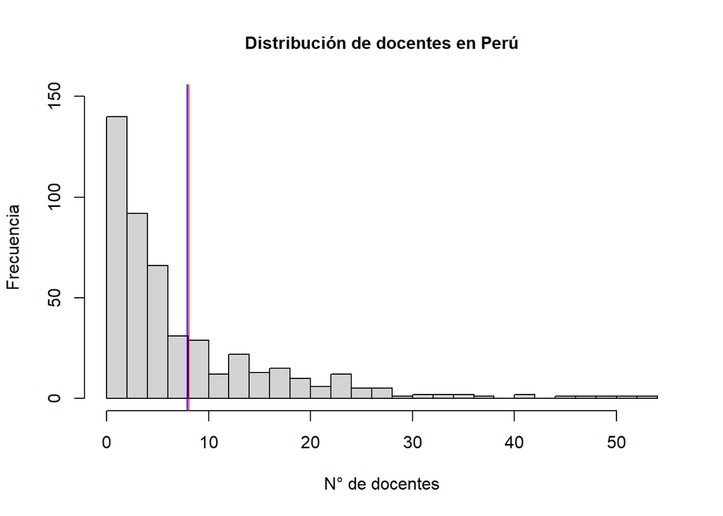

Compararemos lo que nos dice la prueba de hipótesis con la respuesta obtenida directamente de la población. En esta ocasión se propone lo siguiente:

```r
mean(Data$`Docentes (2015)`)
```

```
## [1] 7.932347
```

Ya que se conoce la media de la población, veremos si la prueba de hipótesis coordina con este resultado:

H0 = La media de la población de docentes en el Perú es mayor o igual a 10

```r
hipvarcon(media.mues=mean(MuestraPeruD), mu=10, varia=var(Data$`Docentes (2015)`), signifi=0.05, n=426, alt="izquierda")
```

```
## [1] "La H0 no cumple, se rechaza"
```